# Microeconomics 1021A

September 25, 2020

## Content

- Custom problems
- Problems 20, 21, 22, 23 (p.86)

## Key points

- **Competitive market**
- **Demand**, law of demand
- **Supply**, law of supply
- Market **equilibrium**
- When do we have **Surplus**?
- **Shortage**?

## Custom problem 1

> The \(y\)-intercept of a supply curve is 4. The slope is 2.
1. What is the equation of the supply curve?
2. Suppose that \(Q_S = 5\). What is \(P\)?
3. Suppose that \(P = \$12\). What is \(Q_S\)?

## Custom problem 1

1. \(P = a + bQ_S\)

   \(a=4\), \(b=2\)

   \(\implies\) \(P=4+2Q_S\)
2. \(Q_s=5\)

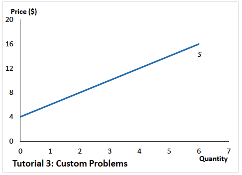

## Custom problem 2

> The \(y\)-intercept of a demand curve is 16. The slope is -4.
1. What is the equation of the demand curve?
2. Suppose that \(Q_D = 3\). What is \(P\)?
3. Suppose that \(P = \$12\). What is \(Q_D\)?

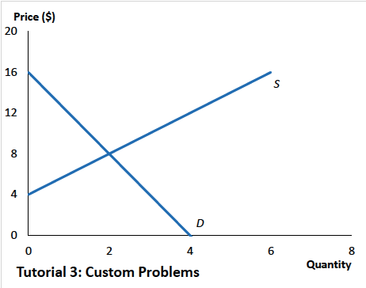

## Custom problem 3

> Use your answers from Custom Problems 1 and 2 to answer the following questions.
1. Suppose the price of the good is $12. Is there a shortage or a surplus, and how does the price adjust?
2. Find the equilibrium price and the equilibrium quantity in this market.

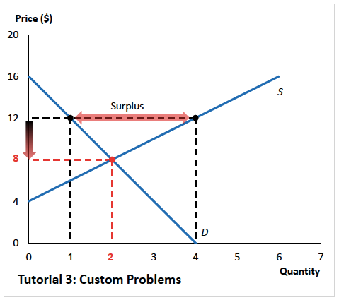

## Problem 3.20

1. Draw a graph of the potato chip market and mark in the equilibrium price and quantity.
2. If the price is 60 cents a bag, is there a shortage or a surplus, and how does the price adjust?

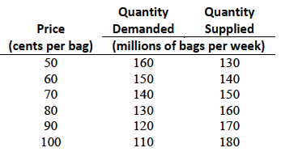

Demand and supply schedules for potato chips

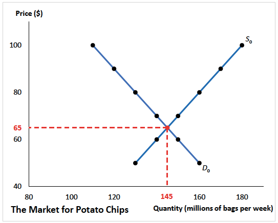

Potato chips equilibrium

## Problem 3.21

> In Problem 3.20, a new dip increases the quantity of potato chips that people want to buy by 30 million bags per week at each price.
1. Does the demand for chips change? Does the supply of chips change? Describe the change.
2. How do the equilibrium price and equilibrium quantity of chips change?

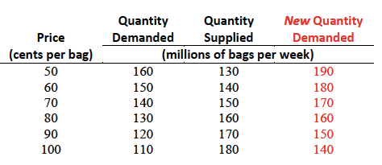

Problem 3.21

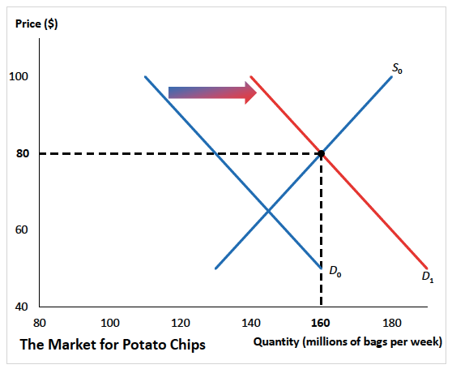

Problem 3.21

## Problem 3.22

> In Problem 3.20, if a virus destroys potato crops and the quantity of potato chips produced decreases by 40 million bags a week at each price, how does the supply of chips change?

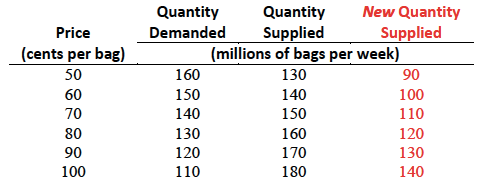

Problem 3.22

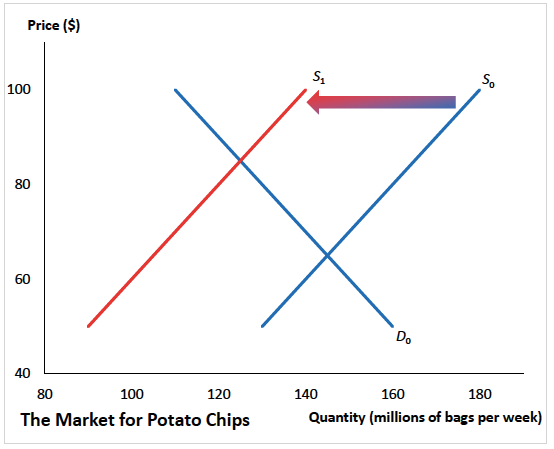

Problem 3.22

## Problem 3.23

> If the virus in Problem 3.22 hits just as the new dip in Problem 3.21 comes onto the market, how do the equilibrium price and equilibrium quantity of chips change?

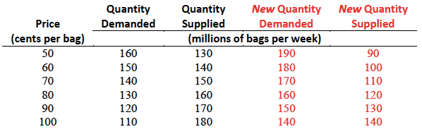

Problem 3.23

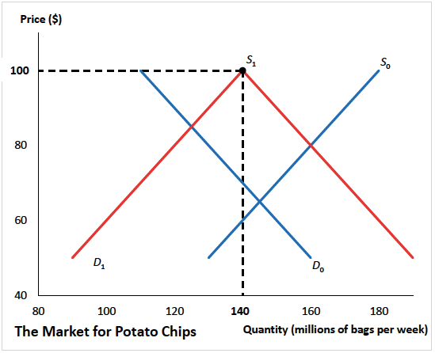

Problem 3.23

## Recap

- Equation of a line: \(Y=a+bX\)
- Supply Curve (positive upward slope): \(P = a + bQ_S\)
- Demand Curve (negative downward slope): \(P = a - bQ_D\)
- Equilibrium: \(Q_S = Q_D\)
- If \(P>P_E \implies Q_S>Q_D \implies\) Surplus
- If \(P<P_E \implies Q_S<Q_D \implies\) Shortage